# analysis-of-world-s-top-chess-players

### Chess

The [International Chess Federation (FIDE)](https://www.fide.com/) governs international chess competition. FIDE used [Elo rating](https://en.wikipedia.org/wiki/Elo_rating_system) system for calculating the relative skill levels of players. In this kernel we will analyse World's Top Chess Players to gain insights about them. We will also see strongest chess playing countries in the world.

[figure not shown]

```python
import pandas as pd
import numpy as np
import matplotlib.pyplot as plt
import seaborn as sns
import warnings as ws
ws.filterwarnings ("ignore")
sns.set_style("white")
```

### Dataset

I have used [World Top Chess Players (August 2020)](https://www.kaggle.com/vikasojha98/world-top-chess-players-august-2020) dataset for our analysis. It contains details of all the chess players in the world sorted by their Standard FIDE rating (highest to lowest) as updated by FIDE in August 2020. The data includes all active and inactive players which can be identified by the Inactive_flag column.

```python
df = pd.read_csv("chess_data.csv")
df.head()
```

|  | Fide id | Name | Federation | Gender | Year_of_birth | Title | Standard_Rating | Rapid_rating | Blitz_rating | Inactive_flag |
| --- | --- | --- | --- | --- | --- | --- | --- | --- | --- | --- |
| 0 | 1503014 | Carlsen, Magnus | NOR | M | 1990.0 | GM | 2863.0 | 2881.0 | 2886.0 | NaN |
| 1 | 2020009 | Caruana, Fabiano | USA | M | 1992.0 | GM | 2835.0 | 2773.0 | 2711.0 | NaN |
| 2 | 4100018 | Kasparov, Garry | RUS | M | 1963.0 | GM | 2812.0 | 2783.0 | 2801.0 | i |
| 3 | 8603677 | Ding, Liren | CHN | M | 1992.0 | GM | 2791.0 | 2836.0 | 2788.0 | NaN |
| 4 | 4168119 | Nepomniachtchi, Ian | RUS | M | 1990.0 | GM | 2784.0 | 2778.0 | 2785.0 | NaN |

For our analysis we will only consider the chess players with their **Standard FIDE Rating >2000**

```python
# Selecting players with Standard_Rating >2000
df = df[df['Standard_Rating']>2000]
```

### Top 10 Chess Players

```python
top_10_players = df.head(10)
top_10_players
```

|  | Fide id | Name | Federation | Gender | Year_of_birth | Title | Standard_Rating | Rapid_rating | Blitz_rating | Inactive_flag |
| --- | --- | --- | --- | --- | --- | --- | --- | --- | --- | --- |
| 0 | 1503014 | Carlsen, Magnus | NOR | M | 1990.0 | GM | 2863.0 | 2881.0 | 2886.0 | NaN |
| 1 | 2020009 | Caruana, Fabiano | USA | M | 1992.0 | GM | 2835.0 | 2773.0 | 2711.0 | NaN |
| 2 | 4100018 | Kasparov, Garry | RUS | M | 1963.0 | GM | 2812.0 | 2783.0 | 2801.0 | i |
| 3 | 8603677 | Ding, Liren | CHN | M | 1992.0 | GM | 2791.0 | 2836.0 | 2788.0 | NaN |
| 4 | 4168119 | Nepomniachtchi, Ian | RUS | M | 1990.0 | GM | 2784.0 | 2778.0 | 2785.0 | NaN |
| 5 | 623539 | Vachier-Lagrave, Maxime | FRA | M | 1990.0 | GM | 2778.0 | 2860.0 | 2822.0 | NaN |
| 6 | 4126025 | Grischuk, Alexander | RUS | M | 1983.0 | GM | 2777.0 | 2784.0 | 2765.0 | NaN |
| 7 | 13300474 | Aronian, Levon | ARM | M | 1982.0 | GM | 2773.0 | 2778.0 | 2739.0 | NaN |
| 8 | 5202213 | So, Wesley | USA | M | 1993.0 | GM | 2770.0 | 2741.0 | 2816.0 | NaN |
| 9 | 13400924 | Radjabov, Teimour | AZE | M | 1987.0 | GM | 2765.0 | 2758.0 | 2757.0 | NaN |

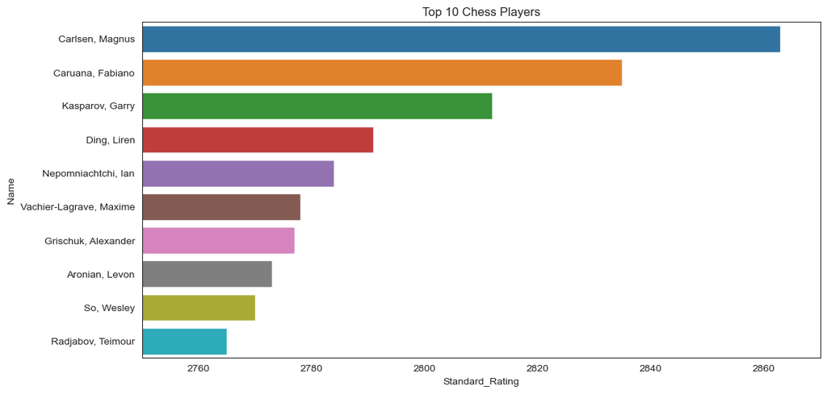

```python
# Rating distribution of Top 10 Chess Players
plt.figure(figsize=(12,6))
plt.title("Top 10 Chess Players")
sns.barplot(x = "Standard_Rating", y = "Name", data=top_10_players).set_xlim(2750, 2870)
plt.show()
```

[figure not shown]

### Top 10 Women Chess Players

```python
top_10_women_players = df[df.Gender=='F'].head(10).reset_index(drop=True)
top_10_women_players
```

|  | Fide id | Name | Federation | Gender | Year_of_birth | Title | Standard_Rating | Rapid_rating | Blitz_rating | Inactive_flag |
| --- | --- | --- | --- | --- | --- | --- | --- | --- | --- | --- |
| 0 | 700070 | Polgar, Judit | HUN | F | 1976.0 | GM | 2675.0 | 2646.0 | 2736.0 | wi |
| 1 | 8602980 | Hou, Yifan | CHN | F | 1994.0 | GM | 2658.0 | 2621.0 | 2601.0 | NaN |
| 2 | 5008123 | Koneru, Humpy | IND | F | 1987.0 | GM | 2586.0 | 2483.0 | 2483.0 | NaN |
| 3 | 4147103 | Goryachkina, Aleksandra | RUS | F | 1998.0 | GM | 2582.0 | 2502.0 | 2441.0 | NaN |
| 4 | 700088 | Polgar, Susan | HUN | F | 1969.0 | GM | 2577.0 | NaN | NaN | wi |
| 5 | 8600147 | Xie, Jun | CHN | F | 1970.0 | GM | 2574.0 | NaN | NaN | wi |
| 6 | 8603006 | Ju, Wenjun | CHN | F | 1991.0 | GM | 2560.0 | 2610.0 | 2536.0 | NaN |
| 7 | 14109336 | Lagno, Kateryna | RUS | F | 1989.0 | GM | 2546.0 | 2521.0 | 2608.0 | NaN |
| 8 | 14114550 | Muzychuk, Mariya | UKR | F | 1992.0 | GM | 2544.0 | 2506.0 | 2326.0 | NaN |
| 9 | 12801259 | Cmilyte, Viktorija | LTU | F | 1983.0 | GM | 2538.0 | 2394.0 | 2435.0 | wi |

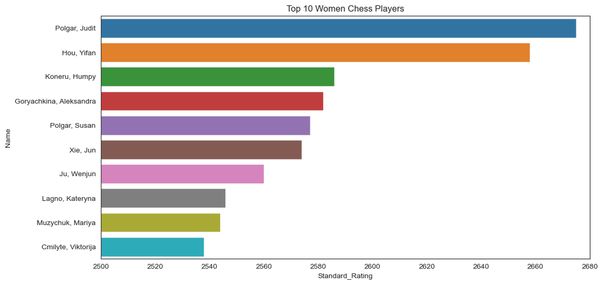

```python
# Rating distribution of Top 10 Women Chess Players
plt.figure(figsize=(12,6))
plt.title("Top 10 Women Chess Players")
sns.barplot(x = "Standard_Rating", y = "Name", data=top_10_women_players).set_xlim(2500, 2680)
plt.show()
```

[figure not shown]

### Hou Yifan

[figure not shown]

### Gender distribution

```
Player's Gender Distribution
M    64765
F     4231
Name: Gender, dtype: int64
```

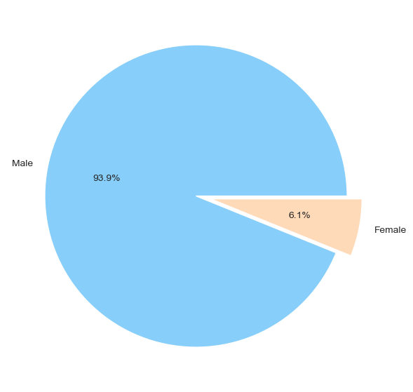

```python
print("Player's Gender Distribution")
print(df.Gender.value_counts())

# Pie chart of Gender distribution on Chess Players
labels = ['Male', 'Female']
sizes = df.Gender.value_counts()
explode = (0, 0.1)
fig1, ax1 = plt.subplots(figsize=(7,7))
ax1.pie(sizes, explode=explode, labels=labels, autopct='%1.1f%%', colors=['lightskyblue', 'peachpuff'])
plt.show()
```

There's huge gender gap in Chess. Only about **6%** of total chess players are women. Thanks to the increasing popularity of the game and more women tournaments, now we are see more young female players emerging :)

```
Grandmaster's Gender Distribution
M    1684
F      37
Name: Gender, dtype: int64
```

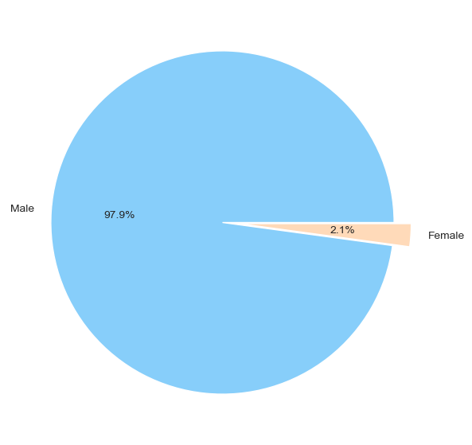

```python
print("Grandmaster's Gender Distribution")
gms = df[df.Title=='GM']
print(gms.Gender.value_counts())

# Pie chart of Gender distribution on Chess Players
labels = ['Male', 'Female']
sizes = gms.Gender.value_counts()
explode = (0, 0.1)
fig1, ax1 = plt.subplots(figsize=(7,7))
ax1.pie(sizes, explode=explode, labels=labels, autopct='%1.1f%%', colors=['lightskyblue', 'peachpuff'])
plt.show()
```

### Age Distribution

```python
# Average age of the chess players
birth_year = df.Year_of_birth.values
age_value =  2020 - birth_year
print("Average age of chess players is", round(np.nanmean(age_value), 1), "years.")
```

```
Average age of chess players is 45.5 years.
```

### Chess Titles Analysis

**FIDE Titles**  
The [International Chess Federation (FIDE)](https://www.fide.com/), awards several performance-based titles to chess players, up to and including the highly prized Grandmaster (GM) title. Titles generally require a combination of [Elo rating](https://en.wikipedia.org/wiki/Elo_rating_system) and norms) (performance benchmarks in competitions including other titled players). Below is the list of major FIDE titles:

**GM** - Grandmaster  
**WGM** - Woman Grandmaster  
**IM** - International Master  
**WIM** - Woman International Master  
**FM** - FIDE Master  
**CM** - FIDE Candidate Master  
**WFM** - Woman FIDE Master  
**WCM** - Woman FIDE Candidate Master  
**WH** - Woman Honorary Grandmaster *(discontinued)*

```
  index  Title
0    FM   7915
1    IM   3866
2    GM   1721
3    CM   1132
4   WFM   1107
5   WIM    708
6   WGM    314
7   WCM     58
8    WH      1
```

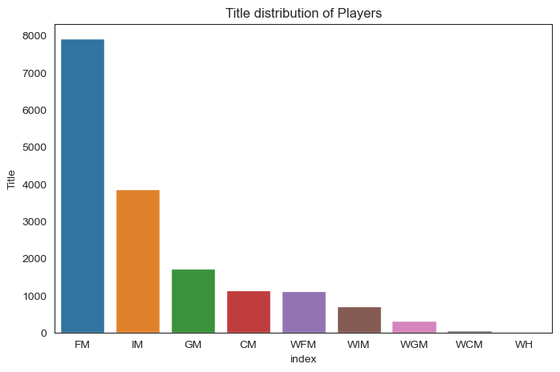

```python
title_dist = df.Title.value_counts().reset_index()
print(title_dist)
plt.figure(figsize=(8,5))
plt.title("Title distribution of Players")
sns.barplot(x = "index", y = "Title", data = title_dist)
plt.show()
```

```
  Title  Standard_Rating
0    GM          2505.37
1    IM          2354.17
2    FM          2252.96
3   WGM          2247.32
4   WIM          2158.47
5    CM          2137.51
6   WFM          2099.27
7    WH          2080.00
8   WCM          2040.40
```

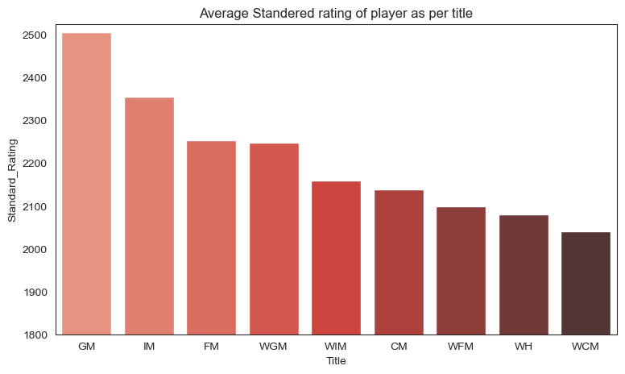

```python
avg_std_rating_per_title = round(df.groupby("Title")["Standard_Rating"].mean(), 2).reset_index().sort_values(by='Standard_Rating', ascending=False).reset_index(drop=True)
print(avg_std_rating_per_title)
plt.figure(figsize=(9,5))
plt.title("Average Standered rating of player as per title")
sns.barplot(x = "Title", y="Standard_Rating", data=avg_std_rating_per_title, palette="Reds_d").set_ylim(1800, 2525)
plt.show()
```

```
  Title  Rapid_rating
0    GM       2493.37
1    IM       2316.89
2   WGM       2199.76
3    FM       2199.60
4   WIM       2094.45
5    CM       2060.32
6   WFM       1992.64
7   WCM       1831.74
8    WH           NaN
```

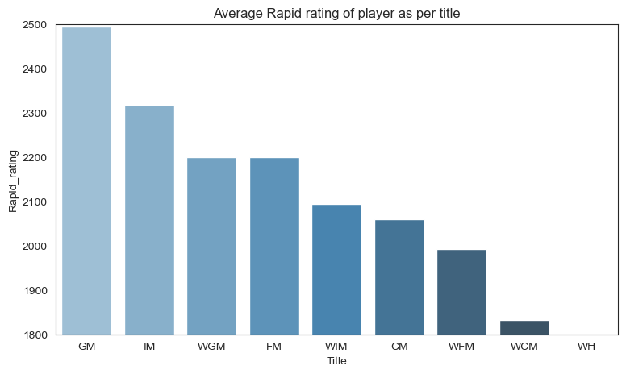

```python
avg_rapid_rating_per_title = round(df.groupby("Title")["Rapid_rating"].mean(), 2).reset_index().sort_values(by='Rapid_rating', ascending=False).reset_index(drop=True)
print(avg_rapid_rating_per_title)
plt.figure(figsize=(9,5))
plt.title("Average Rapid rating of player as per title")
sns.barplot(x = "Title", y="Rapid_rating", data=avg_rapid_rating_per_title, palette="Blues_d").set_ylim(1800, 2500)
plt.show()
```

```
  Title  Blitz_rating
0    GM       2488.78
1    IM       2311.48
2    FM       2197.04
3   WGM       2181.45
4   WIM       2073.68
5    CM       2053.97
6   WFM       1980.94
7   WCM       1835.04
8    WH           NaN
```

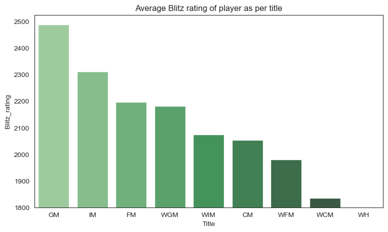

```python
avg_blitz_rating_per_title = round(df.groupby("Title")["Blitz_rating"].mean(), 2).reset_index().sort_values(by='Blitz_rating', ascending=False).reset_index(drop=True)
print(avg_blitz_rating_per_title)
plt.figure(figsize=(9,5))
plt.title("Average Blitz rating of player as per title")
sns.barplot(x = "Title", y="Blitz_rating", data=avg_blitz_rating_per_title, palette="Greens_d").set_ylim(1800, 2525)
plt.show()
```

### Top 10 Chess Playing Countries

```
   Country  Total players
1      RUS           9596
2      GER           8893
3      ESP           3500
4      FRA           2741
5      USA           2554
6      SRB           2204
7      POL           1980
8      UKR           1784
9      CZE           1693
10     HUN           1677
```

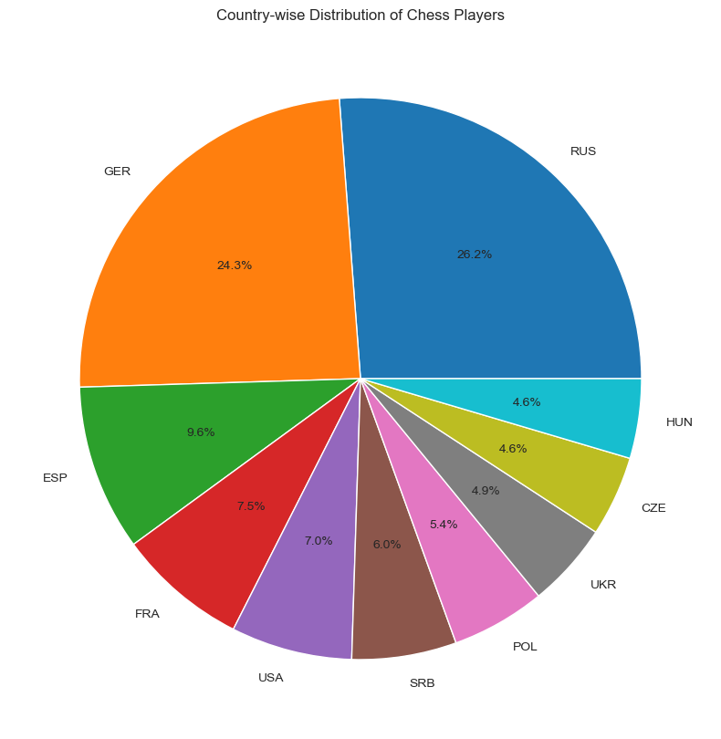

```python
countries_dist = df.Federation.value_counts().reset_index().rename(columns={'index':'Country', 'Federation':'Total players'})[:10]
countries_dist.index += 1
print(countries_dist)

# Pie chart of Country-wise distribution of Chess Players
labels = countries_dist['Country']
sizes = countries_dist['Total players']
fig1, ax1 = plt.subplots(figsize=(10,10))
ax1.pie(sizes, labels=labels, autopct='%1.1f%%')
plt.title("Country-wise Distribution of Chess Players")
plt.show()
```

```
  Country  Total GMs
0     RUS        237
1     GER         96
2     USA         95
3     UKR         88
4     IND         66
5     ESP         55
6     HUN         52
7     FRA         51
8     SRB         50
9     CHN         48
```

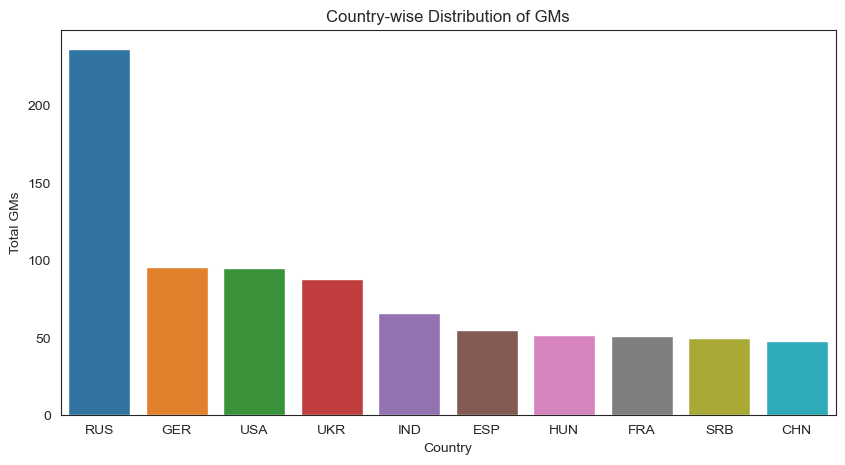

```python
countries_dist = df[df.Title=='GM'].Federation.value_counts().reset_index().rename(columns={'index':'Country', 'Federation':'Total GMs'})[:10]
print(countries_dist)
plt.figure(figsize=(10,5))
plt.title("Country-wise Distribution of GMs")
sns.barplot(x = "Country", y="Total GMs", data=countries_dist)
plt.show()
```

**Russia** has the most number of top chess players in the world. It also has a large number of Grandmasters (237), more than double of next best **Germany** with 96 Grandmasters.

```
  Country  Super GMs
0     RUS         10
1     CHN          5
2     USA          5
3     IND          3
4     AZE          2
5     POL          2
6     NOR          1
7     FID          1
8     VIE          1
9     ESP          1
```

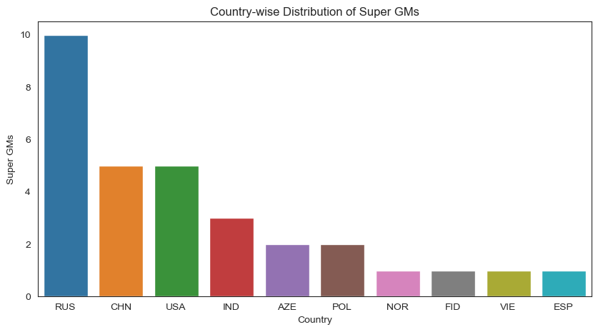

```python
countries_dist = df[df.Standard_Rating>2700].Federation.value_counts().reset_index().rename(columns={'index':'Country', 'Federation':'Super GMs'})[:10]
print(countries_dist)
plt.figure(figsize=(10,5))
plt.title("Country-wise Distribution of Super GMs")
sns.barplot(x = "Country", y="Super GMs", data=countries_dist)
plt.show()
```

Also, we can't forget **Norway** which has only 1 Super GM (**Magnus Carlsen**) dominates the chess in terms of **World Championship** since 2013.